# RNASeq Example Code: Exploratory data analysis reveals surrogate variables – Don’t get burned by the gonads

Alec Steep

20190823

# Example code from a bulk RNA Seq Analysis of Marek’s disease lymphomas seeded in gonadal tissue

## Explanation of Samples and Data

### Sample/File Nomenclature

#### Primary Tumor Samples:

`017834-2` `BIRD#-TUMOR#` `017834`: Bird ID  
`2`: Tumor ID relative to bird (e.g. tumor 2 collected from bird 017834)

#### Replicate Tumor Samples:

`017901-2_2`  
`BIRD#-TUMOR#_Replicate` `017901`: Bird ID  
`2`: Tumor ID relative to bird (e.g. tumor 2 collected from bird 017901)  
`_2`: Identifier of biological replicate from distant side of tumor

#### Primary Control Samples:

`017834-0` `BIRD#-NORMAL` (always 0) `017834`: Bird ID  
`0`: Normal ID (always 0)

## Setup the Environment

```r
############################################################
##### Dependencies #########################################
############################################################

# Load dependencies
#################
#BiocManager::install("SeqGSEA", version = "3.8")
pacs...man <- c("GenomicRanges", "DESeq2","devtools","rafalib","GO.db","vsn","hexbin","ggplot2",
                "GenomicFeatures","Biostrings","BSgenome","AnnotationHub","plyr","dplyr",
                "org.Gg.eg.db","pheatmap","sva","formula.tools","pathview","biomaRt","feather",
                "PROPER","SeqGSEA",'purrr','BioInstaller','RColorBrewer')

# Install packages if need be (NTD: build docker image with dependencies)
new.packages <- pacs...man[!(pacs...man %in% installed.packages()[,"Package"])]
if( length(new.packages) )
        install.packages(new.packages)

lapply(pacs...man, FUN = function(X) {
        do.call("library", list(X))
})
```

[output not shown]

[output cut: 363 more lines]

```r
#################

############################################################
##### Functions ############################################
############################################################

# Make the 'not in' operator
############################
'%!in%' <- function(x,y) {
        !('%in%'(x,y))
}
############################

# Function to relabel RNASeq read names to orthologs
###############################################################################################
chick2ortho_df <- function(x) {
        # Ensure 'x' is a data.frame
        if ( class(x) != "data.frame" ) {
                stop("'x' must be a data frame", class.= FALSE)
        }

        # Load requirements
        library(biomaRt)
        library(purrr)
        library(dplyr)
        # Load in annotations
        mart_gg_ens = useMart("ensembl", dataset="ggallus_gene_ensembl")
        mart_hsa_ens = useMart("ensembl", dataset="hsapiens_gene_ensembl")
        # Create ortholog table
        ortho_df <- getLDS(attributes=c("ensembl_gene_id","hsapiens_homolog_orthology_confidence"),
                           filters="ensembl_gene_id", values = rownames(x), mart=mart_gg_ens,
                           attributesL=c("hgnc_symbol"), martL=mart_hsa_ens) # Use biomart to get orthologs
        # Filter out any low confidence orthologs and any genes that are not one-to-one orthologs in both directions
        ortho_df <- ortho_df[ortho_df$Human.orthology.confidence..0.low..1.high. == '1',]
        ortho_df <- ortho_df[!duplicated(ortho_df[,1]),]
        ortho_df <- ortho_df[!duplicated(ortho_df[,3]),]

        # Assumes that 'x' has ensembl chicken gene ID's as rownames
        # Ensure that only chicken genes appear in the matrix
        x <- x[startsWith(rownames(x), "ENSGALG"),]
        # Assign the HUGO symbols to a new column
        x$hugo <- NA
        x$chick_ens <- rownames(x)

        # Collect the hugo symbols
        ###################################
        get_hugo <- function(x) {
                for ( chick_ens_id in x$chick_ens ) {
                        # Collect the hugo symbol
                        hugo_sym <- ortho_df[ortho_df$Gene.stable.ID == chick_ens_id,]$HGNC.symbol
                        # Assign the hugo symbol to the appropriate column in 'x'
                        x <- mutate(x, hugo = ifelse(x$chick_ens == chick_ens_id, hugo_sym, hugo))
                }
                x
        }
        ###################################
        # Collect the hugo symbols
        x <- get_hugo(x)
        # Remove rows with NA values in hugo field
        x <- x[!is.na(x$hugo),]
        # Set rownames to hugo symbols
        rownames(x) <- x$hugo
        # Remove extra annotation
        drops <- c("hugo", "chick_ens")
        x <- x[,!(names(x) %in% drops)]
        x
}
#########################################################################################

# Capture the Date
date <- format.Date( Sys.Date(), '%Y%m%d' )
```

## Load Data

Data consists of gene count matrix of chicken genes (only those orthologous to human included) across normal and tumor samples. Samples are also annotated with relevent phenotypic data. Files have been formatted for easy pipeline comparison via [BioJupies](https://biojupies.cloud/). Note: load 20190823_biojupiesmatrix_steep.txt into [BioJupies](https://biojupies.cloud/) if you’d like to use gene symbols.

##### Count Matrix Prefiltering:

##### Pheno data file annotation:

- `sample`: Sample ID
- `tissue`: Normal vs. Tumor
  - `NC`: Normal Control
  - `Tu`: Tumor
- `sex`: The sex of the bird
  - `M`: Male
  - `F`: Female
- `ikaros`: Status of IKZF1 mutation or expression (mutation takes presidence)
  - `WT`: Wildtype
  - `MUT`: Nonsynonymous (always in-frame in this cancer) mutation in IKZF1 coding region
  - `LOW`: Comparitevely low IKZF1 expression (compared to normal T cell counts)
- `ikaros_func`: Whether Ikaros activity is inferred to remain functional.
  - `FUNC`: Function maintained (inferred)
  - `LOF`: Loss of DNA-binding domain and tumor suppressor function (inferred)
- `mut`: IKZF1 Mutation status (similar to “ikaros” column)
  - `NO_MUT`: No nonsynonymous mutation detected in IKZF1
  - `MUT`: Nonsynonymous mutation detected in IKZF1
- `replicate`: Whether sample is a biological replicate (`YES`/`NO`)
- `used`: Adjusted purity estimate from linear model
- `purity`: Purity estimate relative to heterozygous (presumably truncal) IKZF1 variant allele frequency

```r
# Load the data
# Pheno data
status <- read.table(file = './data/20190822_metainfo_steep.txt', header = TRUE,
                     row.names = NULL, sep = '\t')

# Raw Counts
all.data <- read.csv(file = './data/20190823_rawcounts_steep.txt', header = TRUE,
                     sep = '\t', check.names=FALSE)
```

#### The Gene Counts (dimhead)

```r
dim(all.data)
```

```
## [1] 26106    32
```

```r
head(all.data,3)
```

```
##                    017733 017748 017820 017824 017936 017939 017945 017947
## ENSGALG00000000004   2217   2284   1449   2009   2641   3043   2211   1652
## ENSGALG00000000011    283    222    202    271    241    327    170    351
## ENSGALG00000000038      0      0      0      0      0      0      0      0
##                    017787-2 017741-1 017766-1 017798-1_1 017798-1_2
## ENSGALG00000000004     1724     1809     2264       2366       2610
## ENSGALG00000000011      126      148      249        388        305
## ENSGALG00000000038        0        0        0          0          0
##                    017794-1 017863-1 017901-2_1 017901-2_2 017911-1_1
## ENSGALG00000000004     2029     1329        969       1708       1951
## ENSGALG00000000011      292      180        272        202        296
## ENSGALG00000000038        0        0          0          0          0
##                    017911-1_2 017835-1 017833-1 017906-1 017855-1_1
## ENSGALG00000000004       1877     1163     1923      593       1569
## ENSGALG00000000011        272      278      237      313        257
## ENSGALG00000000038          0        0        0        0          0
##                    017855-1_2 017738-1 017884-2 017777-3 017842-2_1
## ENSGALG00000000004       1345      449      204     1201       1791
## ENSGALG00000000011        254      317      484      263        235
## ENSGALG00000000038          0        0        0        0          0
##                    017842-2_2 017918-3 017927-2 017841-3
## ENSGALG00000000004       2619     1645     1237      456
## ENSGALG00000000011        285      219      317      305
## ENSGALG00000000038          0        0        0        0
```

#### The Pheno Data (dimhead)

```r
dim(status)
```

```
## [1] 32 10
```

```r
head(status, 32)
```

```
##        sample tissue          sex ikaros ikaros_func    mut replicate
## 1      017733     NC  CD4+ normal     WT        FUNC NO_MUT        NO
## 2      017748     NC  CD4+ normal     WT        FUNC NO_MUT        NO
## 3      017820     NC  CD4+ normal     WT        FUNC NO_MUT        NO
## 4      017824     NC  CD4+ normal     WT        FUNC NO_MUT        NO
## 5      017936     NC  CD4+ normal     WT        FUNC NO_MUT        NO
## 6      017939     NC  CD4+ normal     WT        FUNC NO_MUT        NO
## 7      017945     NC  CD4+ normal     WT        FUNC NO_MUT        NO
## 8      017947     NC  CD4+ normal     WT        FUNC NO_MUT        NO
## 9    017787-2     Tu   Male tumor     WT        FUNC NO_MUT        NO
## 10   017741-1     Tu   Male tumor     WT        FUNC NO_MUT        NO
## 11   017766-1     Tu   Male tumor     WT        FUNC NO_MUT        NO
## 12 017798-1_1     Tu   Male tumor     WT        FUNC NO_MUT        NO
## 13 017798-1_2     Tu   Male tumor     WT        FUNC NO_MUT       YES
## 14   017794-1     Tu   Male tumor     WT        FUNC NO_MUT        NO
```

[output cut: 51 more lines]

```r
# Collect female samples
females <- as.character(filter(status, sex == 'F')$sam)
# Collect male samples
males <- as.character(filter(status, sex == 'M')$sam)
# Collect control samples
controls <- as.character(filter(status, tissue == 'NC')$sam)
# Collect samples
samples <- status$sample
normal_samples <- c('017733','017748','017820','017824','017936','017939','017945','017947')
tumor_samples <- as.character(samples[samples %!in% normal_samples])

# "It is absolutely critical that the columns of the count matrix and the rows of the
# column data (information about samples) are in the same order. DESeq2 will not make
# guesses as to which column of the count matrix belongs to which row of the column data,
# these must be provided to DESeq2 already in consistent order." ~ Mike Love
all.data.m <- as.matrix(all.data)
rownames(status) <- status$sample
all(rownames(status) %in% colnames(all.data.m))
```

```
## [1] TRUE
```

```r
all(rownames(status) == colnames(all.data.m))
```

```
## [1] TRUE
```

```r
all.data.m <- all.data.m[, rownames(status)]
all(rownames(status) == colnames(all.data.m))
```

```
## [1] TRUE
```

```r
##########################################################################
############ Annotate Data for BioJupies #################################
##########################################################################
# Annotate Data for BioJupies
# Annotate normalized counts
biojupes <- all.data
biojupes$ensembl <- rownames(biojupes)
biojupes$symbol <- mapIds(org.Gg.eg.db, biojupes$ensembl, "SYMBOL", "ENSEMBL")
biojupes <- biojupes[!duplicated(biojupes$symbol),]
biojupes <- biojupes[!is.na(biojupes$symbol),]
rownames(biojupes) <- biojupes$symbol
biojupes <- biojupes %>% dplyr::select(symbol, everything())
biojupes <- biojupes %>% dplyr::select(-ensembl)
write.table(biojupes, file = paste0('./data/',date,'_biojupiesmatrix_steep.txt'), quote = FALSE, row.names = FALSE, sep = '\t')
##########################################################################
```

## PCA Analysis

```r
# Perform unsupervised clustering
# Build model
count_data <- all.data.m
col_data <- status # To look at all samples
design = ~ 1 # Primary variable needs to be last
title = paste0('Design: ',as.character(design))
# Create a DESeqDataSet Object
dds <- DESeqDataSetFromMatrix(countData = count_data,
                              colData = col_data,
                              design = design)

# Perform pre-filtering.
# Filter genes with average count of 10 or less.
# Reasoning from:
#citation("PROPER")
dds
```

```
## class: DESeqDataSet
## dim: 26106 32
## metadata(1): version
## assays(1): counts
## rownames(26106): ENSGALG00000000004 ENSGALG00000000011 ...
##   __not_aligned __alignment_not_unique
## rowData names(0):
## colnames(32): 017733 017748 ... 017927-2 017841-3
## colData names(10): sample tissue ... used lane
```

```r
keep <- rowSums(counts(dds))/ncol(dds) >= 10
dds <- dds[keep,]
dds
```

```
## class: DESeqDataSet
## dim: 13314 32
## metadata(1): version
## assays(1): counts
## rownames(13314): ENSGALG00000000004 ENSGALG00000000011 ...
##   __ambiguous __alignment_not_unique
## rowData names(0):
## colnames(32): 017733 017748 ... 017927-2 017841-3
## colData names(10): sample tissue ... used lane
```

```r
dds <- estimateSizeFactors(dds)
rs <- rowSums(counts(dds))
# Normalize the counts
rld <- vst(dds) #vst and rlog comparable with all samples
#rld <- rlog(dds, blind=FALSE)

# Extract matrix of normalized counts
norm_counts <- assay(rld)
counts <- as.data.frame(norm_counts)

# Annotate normalized counts
counts$ensembl <- rownames(counts)
counts$symbol <- mapIds(org.Gg.eg.db, counts$ensembl, "SYMBOL", "ENSEMBL")
counts$entrez <- mapIds(org.Gg.eg.db, counts$ensembl, "ENTREZID", "ENSEMBL")
counts$genename <- mapIds(org.Gg.eg.db, counts$ensembl, "GENENAME", "ENSEMBL")
counts$go <- mapIds(org.Gg.eg.db, counts$ensembl, "GO", "ENSEMBL")
counts$path <- mapIds(org.Gg.eg.db, counts$ensembl, "PATH", "ENSEMBL")
```

### Primary variable of interest (tumors vs normals), unsupervised

Let’s examine our primary dichotomous relationship of interest–tumors vs normals. How well does this relationship explain the variance in our data? Are there other factors influencing our data?

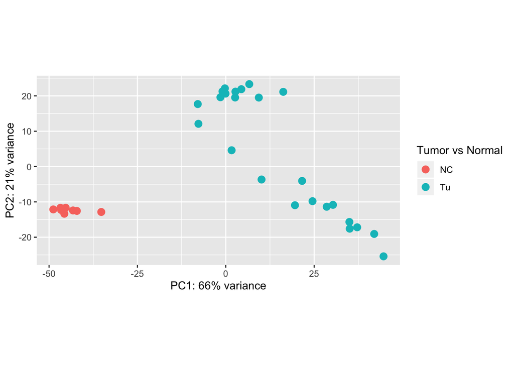

```r
# PCA Analysis (tissue)
DESeq2::plotPCA(rld, intgroup ="tissue") +
        guides(color=guide_legend(title="Tumor vs Normal"))
```

Our normals cluster quite well but there is quite a lot of variance amongst tumor samples. ### Batch effect and technical artifact investigation All sequencing was performed at the same time, place, and machine. Let’s look at the lanes … do we see lane bias?

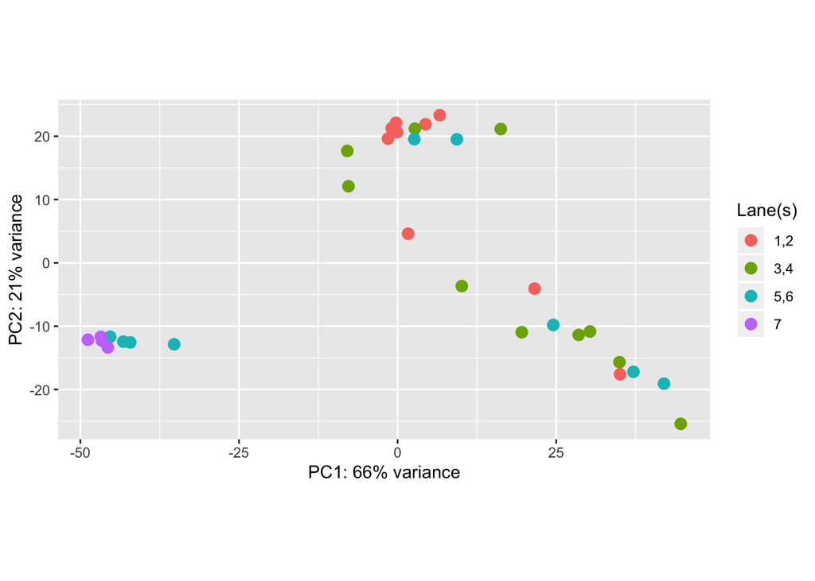

```r
# PCA Analysis (lane)
DESeq2::plotPCA(rld, intgroup ="lane") +
        guides(color=guide_legend(title="Lane(s)"))
```

Our design was not ideal, we sequenced half of our controls in 1 lane (lane 7). This could be a potential lane bias to watch out for, but I think it’s unlikely given distribution of PCs and how tightly the controls cluster (at least compared to tumors).

### Biological Influence (phenotype data) investigation

Let’s examine the sex of the birds. These tumors seeded in gonads–perhaps the organs that differ most between sexes. Note: Normal samples consist of normal CD4+ T cells and tumor samples contain neoplastic CD4+ T cells seeded in gonadal tissue.

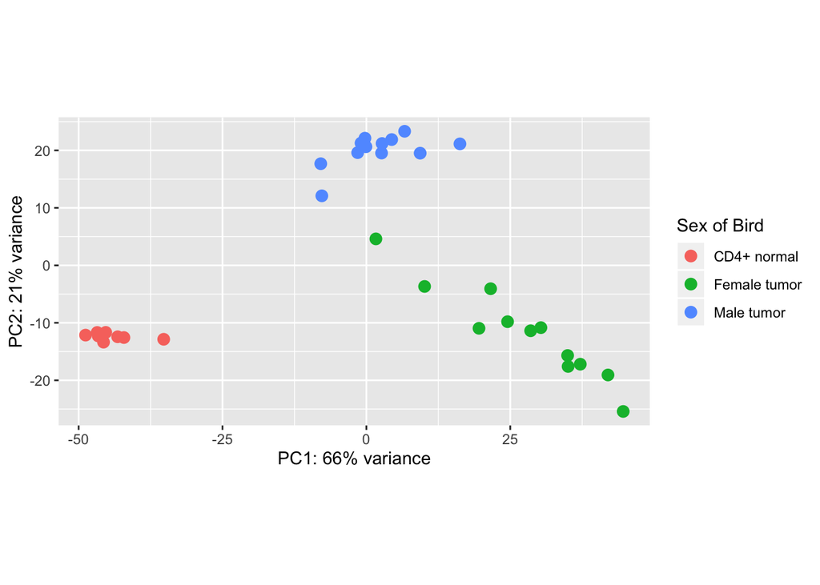

```r
# PCA Analysis (Sex)
DESeq2::plotPCA(rld, intgroup ="sex") +
        guides(color=guide_legend(title="Sex of Bird"))
```

It seems that sex might be driving a significant amount of variance in the gene expression data. Let’s examine the estimated purity of tumors. To estimate tumor purity, we used feature selection (LASSO) and a simple linear model between 2 datasets (DNASeq and RNASeq). MD tumors are usually monoclonal (as were most in this experiment) so we were able to identify truncal mutations (VAFs) and compare those to expression counts of genes with highly conserved expression (e.g. CD4 or IKZF1). Tumor purity analysis not included in this pipeline.

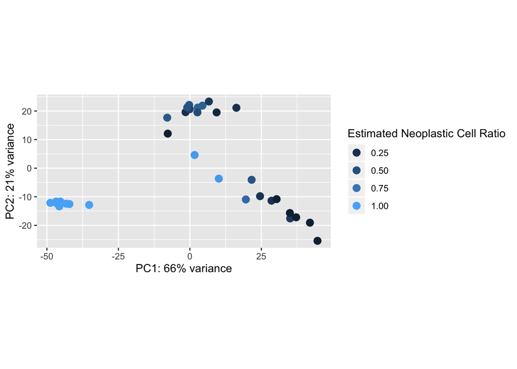

```r
# PCA Analysis (Estimated Tumor Purity)
DESeq2::plotPCA(rld, intgroup ="used") +
        guides(color=guide_legend(title="Estimated Neoplastic Cell Ratio"))
```

Tumor purity status might also be driving a significant amount of variance amongst tumors in the gene expression data.

Ikaros mutations were found across tumors of different phenotypes. They do, however, appear in higher purity female tumors.

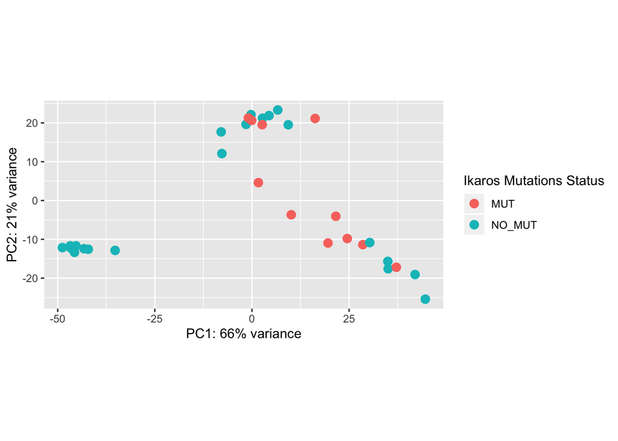

```r
# PCA Analysis (Ikaros Mutations Status)
DESeq2::plotPCA(rld, intgroup ="mut") +
        guides(color=guide_legend(title="Ikaros Mutations Status"))
```

## Surrogate Variable Analysis

To investigate spurious signals, surrogate variable analysis (SVA) was performed incorporating the primary variable of interest: tumor versus normal. There was not significant evidence of influence from technical factors (i.e. date, lane, and location). The top 2 factors correlated with: the top surrogate variable were sex (p = 2.991e-07) and tumor purity (p = 0.009172).

```r
# Perform surrogate variable analysis to show a correlation between hypothetical surrogate variables and purity
##################################################################################################################
############################################################################
############### SVA ########################################################
############################################################################

# Compare tumor vs normal to an unsupervised model. Do any other varibales hide behind the comparison of interest (tumor vs normal?)
## Perform surrogate variable analysis (sva) to look for hidden variation in the data
design = ~ tissue
n.sv <- 2 # Number of surrogate variables
# Perform SVA analysis

dat <- counts(dds, normalized=FALSE)
idx <- rowMeans(dat) > 1
dat <- dat[idx,]
mod <- model.matrix(design, colData(dds))
mod0 <- model.matrix(~ 1, colData(dds))
svseq <- svaseq(dat, mod, mod0, n.sv=n.sv)
```

```
## Number of significant surrogate variables is:  2
## Iteration (out of 5 ):1  2  3  4  5
```

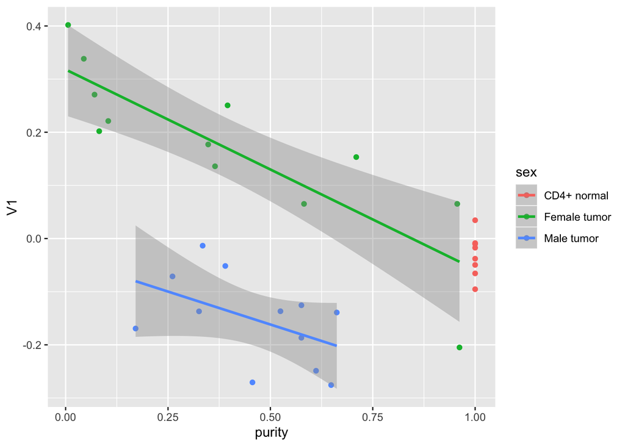

```r
# Combine the data into a plot
plot_df <- cbind(colData(dds), as.data.frame(svseq$sv))
plot_df <- as.data.frame(plot_df)
# Exmaine 'purity' relationship
ggplot(plot_df, aes(x=purity, y=V1, color = sex)) +
        geom_point() +
        stat_smooth(method = 'lm')
```

```r
# Perform linear model and see of there's a correlation
mod <- lm(V1 ~ purity, data=plot_df)
summary(mod)
```

```
##
## Call:
## lm(formula = V1 ~ purity, data = plot_df)
##
## Residuals:
##      Min       1Q   Median       3Q      Max
## -0.29708 -0.12872  0.05873  0.11473  0.26876
##
## Coefficients:
##             Estimate Std. Error t value Pr(>|t|)
## (Intercept)  0.13456    0.05623   2.393  0.02316 *
## purity      -0.23709    0.08512  -2.786  0.00917 **
## ---
## Signif. codes:  0 '***' 0.001 '**' 0.01 '*' 0.05 '.' 0.1 ' ' 1
##
## Residual standard error: 0.1627 on 30 degrees of freedom
## Multiple R-squared:  0.2055, Adjusted R-squared:  0.179
## F-statistic: 7.759 on 1 and 30 DF,  p-value: 0.009172
```

```r
mod <- lm(V1 ~ sex, data=plot_df)
summary(mod)
```

```
##
## Call:
## lm(formula = V1 ~ sex, data = plot_df)
##
## Residuals:
##      Min       1Q   Median       3Q      Max
## -0.37800 -0.03518  0.01352  0.05253  0.22884
##
## Coefficients:
##                 Estimate Std. Error t value Pr(>|t|)
## (Intercept)     -0.03128    0.03911  -0.800 0.430350
## sexFemale tumor  0.20433    0.05049   4.047 0.000352 ***
## sexMale tumor   -0.12092    0.05049  -2.395 0.023310 *
## ---
## Signif. codes:  0 '***' 0.001 '**' 0.01 '*' 0.05 '.' 0.1 ' ' 1
##
## Residual standard error: 0.1106 on 29 degrees of freedom
## Multiple R-squared:  0.6451, Adjusted R-squared:  0.6207
## F-statistic: 26.36 on 2 and 29 DF,  p-value: 2.991e-07
```

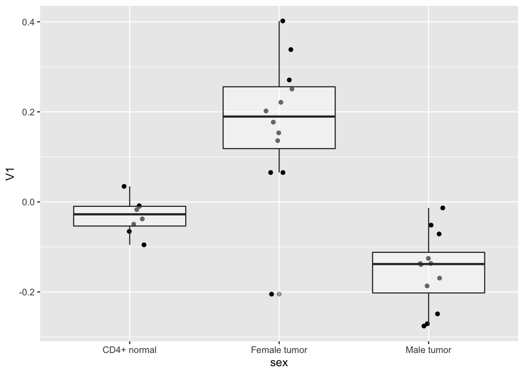

```r
# Show that sex was successfully corrected for
# Exmaine the sex relationship
ggplot(plot_df, aes(x=sex, y=V1)) +
        geom_jitter(width=0.1) +
        geom_boxplot(alpha = 0.4)
```

```r
mod <- aov(V1~sex,data = plot_df)
summary(mod)
```

```
##             Df Sum Sq Mean Sq F value   Pr(>F)
## sex          2 0.6451  0.3226   26.36 2.99e-07 ***
## Residuals   29 0.3549  0.0122
## ---
## Signif. codes:  0 '***' 0.001 '**' 0.01 '*' 0.05 '.' 0.1 ' ' 1
```

### Adjust Model for Tumor Purity

We will (arbitrarily) remove tumor samples with an estimated tumor purity less than 25%. Sex seemed to drive much of the variance amongst tumors, however, we cannot reasonably attempt to correct for this. `sex` really represents infiltrating gondal tissue in tumors; normal samples were T cells. We may be able to adjust for purity. Let’s rerun the PCA when adjusting for purity.

```r
##############################################################################
######## Model Adjustment, PCA, Differential Gene Expression Analysis  #######
##############################################################################

# Pheno data
status <- read.table(file = './data/20190822_metainfo_steep.txt', header = TRUE,
                     row.names = NULL, sep = '\t')
# Raw Counts
all.data <- read.csv(file = './data/20190823_rawcounts_steep.txt', header = TRUE,
                     sep = '\t', check.names=FALSE)

# Adjust the status dataframe to only include samples with purity > 25%
status <- filter(status, purity > 0.25) # TCGA maintains higher purity standards
#status <- filter(status, tissue == 'Tu')

# Collect female samples
females <- as.character(filter(status, sex == 'F')$sam)
# Collect male samples
males <- as.character(filter(status, sex == 'M')$sam)
# Collect control samples
controls <- as.character(filter(status, tissue == 'NC')$sam)
# Collect samples
samples <- status$sam

# Make sure rownames of status equal samples
rownames(status) <- status$sam

# Account for estimated purity in design
DE_design = ~ purity

# Save the formula in string form
form <- as.character(DE_design)

# Perform DESeq analysi with males and females seperately (sex of bird is confounding)
all.data.m <- as.matrix(all.data)
all(rownames(status) %in% colnames(all.data.m))
```

```
## [1] TRUE
```

```r
all.data.s <- all.data.m[, rownames(status)]
all(rownames(status) == colnames(all.data.s))
```

```
## [1] TRUE
```

```r
##### Apply differential gene expression analysis with DESeq2
lfc=0.5
qval=0.05

# Apply differential gene expression analysis with DESeq2
count_data <- all.data.s
col_data <- status
design = DE_design # Primary variable needs to be last
title = paste0('Design: ',as.character(design))
# Create a DESeqDataSet Object
dds <- DESeqDataSetFromMatrix(countData = count_data,
                              colData = col_data,
                              design = design)
# Perform pre-filtering.
# Filter genes with average count of 10 or less.
# Reasoning from:
#citation("PROPER")
keep <- rowSums(counts(dds))/ncol(dds) >= 10
dds <- dds[keep,]
dds
```

```
## class: DESeqDataSet
## dim: 12956 26
## metadata(1): version
## assays(1): counts
## rownames(12956): ENSGALG00000000004 ENSGALG00000000011 ...
##   __ambiguous __alignment_not_unique
## rowData names(0):
## colnames(26): 017733 017748 ... 017918-3 017927-2
## colData names(10): sample tissue ... used lane
```

```r
# Ensure the factor levels are properly set
dds$tissue <- relevel(dds$tissue, ref = "NC")

# Perform differential expression analysis
dds <- estimateSizeFactors(dds)
rs <- rowSums(counts(dds))
rld <- DESeq2::vst(dds, blind=FALSE)
counts <- as.data.frame(assay(rld))
counts$ensembl <- rownames(counts)
counts$symbol <- mapIds(org.Gg.eg.db, rownames(counts), "SYMBOL", "ENSEMBL")
dds <- DESeq(dds)
res <- results(dds)
res
```

```
## log2 fold change (MLE): purity
## Wald test p-value: purity
## DataFrame with 12956 rows and 6 columns
##                                baseMean      log2FoldChange
##                               <numeric>           <numeric>
## ENSGALG00000000004     1824.13651209093   0.879599131473557
## ENSGALG00000000011     257.129478765991 -0.0166217470720345
## ENSGALG00000000048     106.321431606088    3.90177619922934
## ENSGALG00000000055     954.570603527397  -0.528643474419875
## ENSGALG00000000067     128.974333145359    -1.4521020374817
## ...                                 ...                 ...
## ENSGALG00000043828     781.789107013598   -1.62525712534002
## ENSGALG00000043831     61.5087349573817   -6.54911732711256
## __no_feature           16424760.2428546    1.25526784014696
## __ambiguous            108331.395989063   0.428278008300241
## __alignment_not_unique 4145376.04267432   0.425224475356784
##                                    lfcSE                stat
##                                <numeric>           <numeric>
## ENSGALG00000000004     0.297452918920478    2.95710371465109
## ENSGALG00000000011      0.27786134383514 -0.0598202932535173
## ENSGALG00000000048      0.98175025967917    3.97430625636342
## ENSGALG00000000055     0.398745115432079   -1.32576790024635
## ENSGALG00000000067     0.707356297325936   -2.05285800518235
## ...                                  ...                 ...
## ENSGALG00000043828     0.353292118720654   -4.60032092203309
## ENSGALG00000043831      1.09339661193231   -5.98969967131924
## __no_feature           0.288688501372904    4.34817401516627
## __ambiguous            0.171140280242365    2.50249682712757
## __alignment_not_unique 0.228265242966438    1.86285248612863
##                                      pvalue                 padj
##                                   <numeric>            <numeric>
## ENSGALG00000000004      0.00310543643252373   0.0076519654659143
## ENSGALG00000000011        0.952298762839853    0.963378056637241
## ENSGALG00000000048     7.05846918075601e-05 0.000274705697524406
## ENSGALG00000000055        0.184916588607379    0.251314310500074
## ENSGALG00000000067       0.0400863509246856   0.0688348260543707
## ...                                     ...                  ...
## ENSGALG00000043828     4.21840536134352e-06 2.22621832430007e-05
## ENSGALG00000043831     2.10228886715697e-09 2.65211826318264e-08
## __no_feature           1.37275668269271e-05 6.35875422987726e-05
## __ambiguous              0.0123320730871495   0.0251059614891748
## __alignment_not_unique   0.0624830232342254    0.100238547880906
```

```r
res.thr <- results(dds, lfcThreshold=lfc, alpha=qval)
summary(res.thr)
```

```
##
## out of 12956 with nonzero total read count
## adjusted p-value < 0.05
## LFC > 0.50 (up)    : 1560, 12%
## LFC < -0.50 (down) : 2712, 21%
## outliers [1]       : 0, 0%
## low counts [2]     : 0, 0%
## (mean count < 7)
## [1] see 'cooksCutoff' argument of ?results
## [2] see 'independentFiltering' argument of ?results
```

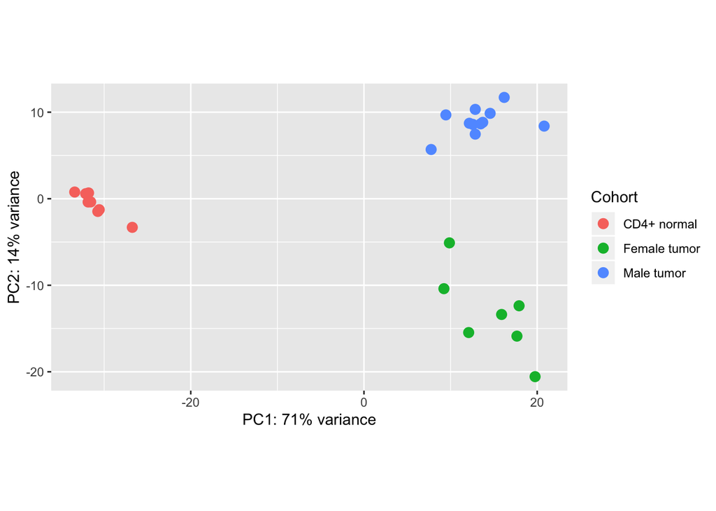

```r
res.thr$ensembl <- rownames(res.thr)
res.thr$symbol <- mapIds(org.Gg.eg.db, rownames(res.thr), "SYMBOL", "ENSEMBL")
res.thr$entrez <- mapIds(org.Gg.eg.db, rownames(res.thr), "ENTREZID", "ENSEMBL")
res.thr$genename <- mapIds(org.Gg.eg.db, rownames(res.thr), "GENENAME", "ENSEMBL")
res.thr$go <- mapIds(org.Gg.eg.db, rownames(res.thr), "GO", "ENSEMBL")
res.thr$path <- mapIds(org.Gg.eg.db, rownames(res.thr), "PATH", "ENSEMBL")
resSort <- res.thr[order(res.thr$padj),]
num <- as.numeric(table(resSort$padj < qval)[2])
topgenes <- head(rownames(resSort),num)

# PCA Analysis (Cohort)
DESeq2::plotPCA(rld, intgroup ="sex") +
        guides(color=guide_legend(title="Cohort"))
```

The variance between samples of different sexes and estimated tumor purity reduced, while the variance between the primary dichotomous relationship of interest—MD tumors versus CD4+ normal samples increased.

### Visulaize Differentially Expressed Genese (Tumors vs Normals)

```r
# Extract significant results
resSig <- head(resSort, n = num)
mat <- assay(rld)[topgenes,]
# Expression is regularized log, then subtracted by rowmeans
mat <- mat - rowMeans(mat)

#remove NA values
mat <- mat[!is.na(rownames(mat)),]

# Extract the annotation information
hm_title <- c("sex","purity",'mut')
df <- as.data.frame(colData(dds)[,hm_title])
df$mut <- as.character(df$mut)
df[df$mut == "NO_MUT",]$mut <- 'Wt'
df[df$mut == "MUT",]$mut <- 'Mutant'
df$mut <- as.factor(df$mut)
names(df) <- c('Sample status','Estimated purity','IKZF1 status')

# Subset samples to make plotting easy
#n500 <- sample(nrow(counts), 500)
#counts_hm <- counts[n500,]
# Remove controls
colnames(mat)
```

```
##  [1] "017733"     "017748"     "017820"     "017824"     "017936"
##  [6] "017939"     "017945"     "017947"     "017787-2"   "017766-1"
## [11] "017798-1_1" "017798-1_2" "017794-1"   "017863-1"   "017901-2_1"
## [16] "017901-2_2" "017911-1_1" "017911-1_2" "017835-1"   "017833-1"
## [21] "017906-1"   "017777-3"   "017842-2_1" "017842-2_2" "017918-3"
## [26] "017927-2"
```

```r
#mat <- mat[,c(9:26)]
dim(mat)
```

```
## [1] 4272   26
```

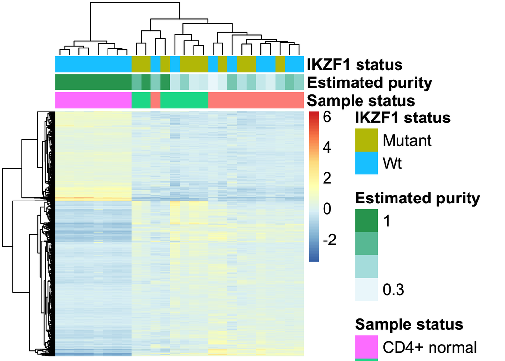

```r
#x <- as.data.frame(mat)
#write.table(x, file = './data/mat_tumors_de_genes_4heatmap.txt', quote = FALSE,
#            row.names = FALSE, sep = '\t')

#############################################################################
########## Quickly generate tumor heatmap of gene expression ################
#############################################################################
# Load the file
# x <- read.csv(file = './data/mat_tumors_de_genes_4heatmap.txt', sep = '\t')
#x <- as.matrix(x)
x <- mat

hm <- pheatmap(x, annotation_col=df, fontsize = 16,
               show_rownames=FALSE,show_colnames=FALSE)
hm
```

```r
#############################################################################
#############################################################################
#############################################################################
```

#### This was a modest attempt to understand what was driving the variance in our gene expression datasets.